# Data Summarization

## Data Summarization

- Basic statistical summarization
  - `mean(x)`: takes the mean of x
  - `sd(x)`: takes the standard deviation of x
  - `median(x)`: takes the median of x
  - `quantile(x)`: displays sample quantities of x. Default is min, IQR, max
  - `range(x)`: displays the range. Same as c(min(x), max(x))
  - `sum(x)`: sum of x
- Transformations
  - `log` - log (base `e`) transformation
  - `log2` - log base 2 transform
  - `log10` - log base 10 transform
  - `sqrt` - square root

## Some examples

We can use the `mtcars` to explore different ways of summarizing data. The `head` command displays the first `6` (default) rows of an object:

```r
head(mtcars)
```

```
                   mpg cyl disp  hp drat    wt  qsec vs am gear carb
Mazda RX4         21.0   6  160 110 3.90 2.620 16.46  0  1    4    4
Mazda RX4 Wag     21.0   6  160 110 3.90 2.875 17.02  0  1    4    4
Datsun 710        22.8   4  108  93 3.85 2.320 18.61  1  1    4    1
Hornet 4 Drive    21.4   6  258 110 3.08 3.215 19.44  1  0    3    1
Hornet Sportabout 18.7   8  360 175 3.15 3.440 17.02  0  0    3    2
Valiant           18.1   6  225 105 2.76 3.460 20.22  1  0    3    1
```

## Statistical summarization

Note - the `$` references/selects columns from a `data.frame`/`tibble`:

```r
mean(mtcars$hp)
```

```
[1] 146.6875
```

```r
quantile(mtcars$hp)
```

```
   0%   25%   50%   75%  100%
 52.0  96.5 123.0 180.0 335.0
```

## Statistical summarization

```r
median(mtcars$wt)
```

```
[1] 3.325
```

```r
quantile(mtcars$wt, probs = 0.6)
```

```
 60%
3.44
```

## Statistical summarization

`t.test` will be covered more in detail later, gives a mean and 95% CI:

```r
t.test(mtcars$wt)
```

```
    One Sample t-test

data:  mtcars$wt
t = 18.6, df = 31, p-value < 2.2e-16
alternative hypothesis: true mean is not equal to 0
95 percent confidence interval:
 2.864478 3.570022
sample estimates:
mean of x
  3.21725
```

## Statistical summarization

Note that many of these functions have additional inputs regarding missing data, typically requiring the `na.rm` argument ("remove NAs").

```r
x = c(1,5,7,NA,4,2, 8,10,45,42)
mean(x)
```

```
[1] NA
```

```r
mean(x, na.rm = TRUE)
```

```
[1] 13.77778
```

```r
quantile(x, na.rm = TRUE)
```

```
  0%  25%  50%  75% 100%
   1    4    7   10   45
```

## Data Summarization on matrices/data frames

- Basic statistical summarization
  - `rowMeans(x)`: takes the means of each row of x
  - `colMeans(x)`: takes the means of each column of x
  - `rowSums(x)`: takes the sum of each row of x
  - `colSums(x)`: takes the sum of each column of x
  - `summary(x)`: for data frames, displays the quantile information

## TB Incidence

Please download the TB incidence data:

http://www.aejaffe.com/winterR_2017/data/tb_incidence.xlsx

Here we will read in a `data.frame` of values from TB incidence:

```r
library(readxl)
tb <- read_excel("../../data/tb_incidence.xlsx")
head(tb)
```

```
# A tibble: 6 × 19
  `TB incidence, all forms (per 100 000 population per year)` `1990`
                                                        <chr>  <dbl>
1                                                 Afghanistan    168
2                                                     Albania     25
3                                                     Algeria     38
4                                              American Samoa     21
5                                                     Andorra     36
6                                                      Angola    205
# ... with 17 more variables: `1991` <dbl>, `1992` <dbl>, `1993` <dbl>,
#   `1994` <dbl>, `1995` <dbl>, `1996` <dbl>, `1997` <dbl>, `1998` <dbl>,
#   `1999` <dbl>, `2000` <dbl>, `2001` <dbl>, `2002` <dbl>, `2003` <dbl>,
#   `2004` <dbl>, `2005` <dbl>, `2006` <dbl>, `2007` <dbl>
```

## Indicator of TB

We can rename the first column to be the country measured using the `rename` function in `dplyr` (we have to use the ` things because there are spaces in the name):

```r
library(dplyr)
tb = rename(tb,
            country = `TB incidence, all forms (per 100 000 population per year)`)
```

`colnames` will show us the column names and sho that country is renamed:s

```r
colnames(tb)
```

```
 [1] "country" "1990"    "1991"    "1992"    "1993"    "1994"    "1995"
 [8] "1996"    "1997"    "1998"    "1999"    "2000"    "2001"    "2002"
[15] "2003"    "2004"    "2005"    "2006"    "2007"
```

## Column and Row means

`colMeans` and `rowMeans` must work on all numeric data. We will subset years before 2000 (starting with 1):

```r
avgs = select(tb, starts_with("1"))
colMeans(avgs, na.rm = TRUE)
```

```
    1990     1991     1992     1993     1994     1995     1996     1997
105.5797 107.6715 108.3140 110.3188 111.9662 114.1981 115.3527 118.8792
    1998     1999
121.5169 125.0435
```

```r
tb$before_2000_avg = rowMeans(avgs, na.rm = TRUE)
head(tb[, c("country", "before_2000_avg")])
```

```
# A tibble: 6 × 2
         country before_2000_avg
           <chr>           <dbl>
1    Afghanistan           168.0
2        Albania            26.3
3        Algeria            41.8
4 American Samoa             8.5
5        Andorra            28.8
6         Angola           224.6
```

## Summary

Using `summary` can give you rough snapshots of each column, but you would likely use `mean`, `min`, `max`, and `quantile` when necessary:

```r
summary(tb)
```

```
   country               1990            1991            1992
 Length:208         Min.   :  0.0   Min.   :  4.0   Min.   :  2.0
 Class :character   1st Qu.: 27.5   1st Qu.: 27.0   1st Qu.: 27.0
 Mode  :character   Median : 60.0   Median : 58.0   Median : 56.0
                    Mean   :105.6   Mean   :107.7   Mean   :108.3
                    3rd Qu.:165.0   3rd Qu.:171.0   3rd Qu.:171.5
                    Max.   :585.0   Max.   :594.0   Max.   :606.0
                    NA's   :1       NA's   :1       NA's   :1
      1993            1994          1995            1996
 Min.   :  4.0   Min.   :  0   Min.   :  3.0   Min.   :  0.0
 1st Qu.: 27.5   1st Qu.: 26   1st Qu.: 26.5   1st Qu.: 25.5
 Median : 56.0   Median : 57   Median : 58.0   Median : 60.0
 Mean   :110.3   Mean   :112   Mean   :114.2   Mean   :115.4
 3rd Qu.:171.0   3rd Qu.:174   3rd Qu.:177.5   3rd Qu.:179.0
 Max.   :618.0   Max.   :630   Max.   :642.0   Max.   :655.0
 NA's   :1       NA's   :1     NA's   :1       NA's   :1
      1997            1998            1999            2000
 Min.   :  0.0   Min.   :  0.0   Min.   :  0.0   Min.   :  0.0
 1st Qu.: 24.5   1st Qu.: 23.5   1st Qu.: 22.5   1st Qu.: 21.5
 Median : 64.0   Median : 63.0   Median : 66.0   Median : 60.0
 Mean   :118.9   Mean   :121.5   Mean   :125.0   Mean   :127.8
 3rd Qu.:181.0   3rd Qu.:188.5   3rd Qu.:192.5   3rd Qu.:191.0
 Max.   :668.0   Max.   :681.0   Max.   :695.0   Max.   :801.0
 NA's   :1       NA's   :1       NA's   :1       NA's   :1
      2001            2002            2003             2004
 Min.   :  0.0   Min.   :  3.0   Min.   :   0.0   Min.   :   0
 1st Qu.: 19.0   1st Qu.: 20.5   1st Qu.:  17.5   1st Qu.:  18
 Median : 59.0   Median : 60.0   Median :  56.0   Median :  56
 Mean   :130.7   Mean   :136.2   Mean   : 136.2   Mean   : 137
 3rd Qu.:189.5   3rd Qu.:195.5   3rd Qu.: 189.0   3rd Qu.: 184
 Max.   :916.0   Max.   :994.0   Max.   :1075.0   Max.   :1127
 NA's   :1       NA's   :1       NA's   :1        NA's   :1
      2005              2006              2007        before_2000_avg
 Min.   :   0.00   Min.   :   0.00   Min.   :   0.0   Min.   :  3.50
 1st Qu.:  16.75   1st Qu.:  16.75   1st Qu.:  15.5   1st Qu.: 26.45
 Median :  53.50   Median :  55.50   Median :  53.0   Median : 61.20
 Mean   : 135.67   Mean   : 134.61   Mean   : 133.4   Mean   :113.88
 3rd Qu.: 183.75   3rd Qu.: 185.00   3rd Qu.: 186.5   3rd Qu.:175.20
 Max.   :1141.00   Max.   :1169.00   Max.   :1198.0   Max.   :637.10
                                     NA's   :1        NA's   :1
```

## Apply statements

You can apply more general functions to the rows or columns of a matrix or data frame, beyond the mean and sum.

```
apply(X, MARGIN, FUN, ...)
```

> X : an array, including a matrix.

> MARGIN : a vector giving the subscripts which the function will be applied over. E.g., for a matrix 1 indicates rows, 2 indicates columns, c(1, 2) indicates rows and columns. Where X has named dimnames, it can be a character vector selecting dimension names.

> FUN : the function to be applied: see 'Details'.

> … : optional arguments to FUN.

## Apply statements

```r
apply(avgs,2,mean,na.rm=TRUE) # column means
```

```
    1990     1991     1992     1993     1994     1995     1996     1997
105.5797 107.6715 108.3140 110.3188 111.9662 114.1981 115.3527 118.8792
    1998     1999
121.5169 125.0435
```

```r
apply(avgs,2,sd,na.rm=TRUE) # columns sds
```

```
    1990     1991     1992     1993     1994     1995     1996     1997
110.6440 112.7687 114.4853 116.6744 120.0931 122.7119 126.1800 131.0858
    1998     1999
137.3754 146.0755
```

```r
apply(avgs,2,max,na.rm=TRUE) # column maxs
```

```
1990 1991 1992 1993 1994 1995 1996 1997 1998 1999
 585  594  606  618  630  642  655  668  681  695
```

## Other Apply Statements

- `tapply()`: 'grouping' apply
- `lapply()`: 'list' apply [tomorrow]
- `sapply()`: 'simple' apply [tomorrow]
- Other less used ones…

See more details here: http://nsaunders.wordpress.com/2010/08/20/a-brief-introduction-to-apply-in-r/

## Youth Tobacco Survey

Please download the Youth Tobacco Survey data. You can also read it in directly from the web:

```r
library(readr)
smoke = read_csv(
  "http://www.aejaffe.com/winterR_2017/data/Youth_Tobacco_Survey_YTS_Data.csv")
head(smoke)
```

```
# A tibble: 6 × 31
   YEAR LocationAbbr LocationDesc                 TopicType
  <int>        <chr>        <chr>                     <chr>
1  2015           AZ      Arizona Tobacco Use – Survey Data
2  2015           AZ      Arizona Tobacco Use – Survey Data
3  2015           AZ      Arizona Tobacco Use – Survey Data
4  2015           AZ      Arizona Tobacco Use – Survey Data
5  2015           AZ      Arizona Tobacco Use – Survey Data
6  2015           AZ      Arizona Tobacco Use – Survey Data
# ... with 27 more variables: TopicDesc <chr>, MeasureDesc <chr>,
#   DataSource <chr>, Response <chr>, Data_Value_Unit <chr>,
#   Data_Value_Type <chr>, Data_Value <dbl>,
#   Data_Value_Footnote_Symbol <chr>, Data_Value_Footnote <chr>,
#   Data_Value_Std_Err <dbl>, Low_Confidence_Limit <dbl>,
#   High_Confidence_Limit <dbl>, Sample_Size <int>, Gender <chr>,
#   Race <chr>, Age <chr>, Education <chr>, GeoLocation <chr>,
#   TopicTypeId <chr>, TopicId <chr>, MeasureId <chr>,
#   StratificationID1 <chr>, StratificationID2 <chr>,
#   StratificationID3 <chr>, StratificationID4 <chr>, SubMeasureID <chr>,
#   DisplayOrder <int>
```

## Length and unique

`unique(x)` will return the unique elements of `x`

```r
unique(smoke$LocationDesc)[1:10]
```

```
 [1] "Arizona"                  "Connecticut"
 [3] "Georgia"                  "Hawaii"
 [5] "Illinois"                 "Louisiana"
 [7] "Mississippi"              "Utah"
 [9] "Missouri"                 "National (States and DC)"
```

`length` will tell you the length of a vector. Combined with `unique`, tells you the number of unique elements:

```r
length(unique(smoke$LocationDesc))
```

```
[1] 50
```

## Table

`table(x)` will return a frequency table of unique elements of `x`

```r
table(smoke$LocationDesc)[1:5]
```

```
   Alabama    Arizona   Arkansas California   Colorado
       378        240        210         96         48
```

## Subsetting to specific columns

Let's just take smoking status measures for all genders using `filter`, and the columns that represent the year, state using `select`:

```r
library(dplyr)
sub_smoke = filter(smoke,
                   MeasureDesc == "Smoking Status",
                   Gender == "Overall",
                   Response == "Current")
sub_smoke = select(sub_smoke, YEAR, LocationDesc, Data_Value)
head(sub_smoke, 4)
```

```
# A tibble: 4 × 3
   YEAR LocationDesc Data_Value
  <int>        <chr>      <dbl>
1  2015      Arizona        3.2
2  2015  Connecticut        0.8
3  2015  Connecticut        5.6
4  2015      Georgia       10.8
```

## `tapply()`

From the help file: "Apply a function to each cell of a ragged array, that is to each (non-empty) group of values given by a unique combination of the levels of certain factors."

```
tapply(X, INDEX, FUN = NULL, ..., simplify = TRUE)
```

Simply put, you can apply function `FUN` to `X` within each categorical level of `INDEX`. It is very useful for assessing properties of continuous data by levels of categorical data.

## `tapply()`

For example, we can estimate the average current smoking statuses over all states for each year:

```r
tapply(sub_smoke$Data_Value, sub_smoke$YEAR, mean, na.rm = TRUE)
```

```
     1999      2000      2001      2002      2003      2004      2005
20.493333 19.878431 15.661111 16.802326 13.176190 13.926923 14.128571
     2006      2007      2008      2009      2010      2011      2012
14.113636 13.013636 12.159091 11.663333 12.290000 11.773913  9.954545
     2013      2014      2015
 7.782759  7.157143  6.579167
```

## Perform Operations By Groups: dplyr

`group_by` allows you group the data in a more intuitive way than `tapply`

We will use `group_by` to group the data by line, then use `summarize` (or `summarise`) to get the mean percentage of current smokers:

```r
summarize(group_by(sub_smoke, YEAR), year_avg = mean(Data_Value, na.rm = TRUE))
```

```
# A tibble: 17 × 2
    YEAR  year_avg
   <int>     <dbl>
1   1999 20.493333
2   2000 19.878431
3   2001 15.661111
4   2002 16.802326
5   2003 13.176190
6   2004 13.926923
7   2005 14.128571
8   2006 14.113636
9   2007 13.013636
10  2008 12.159091
11  2009 11.663333
12  2010 12.290000
13  2011 11.773913
14  2012  9.954545
15  2013  7.782759
16  2014  7.157143
17  2015  6.579167
```

## Using the `pipe` (comes with `dplyr`):

Pipe `sub_smoke` into `group_by`, then pipe that into `summarize`:

```r
smoke_avgs = sub_smoke %>%
  group_by(YEAR) %>%
  summarize(year_avg = mean(Data_Value, na.rm = TRUE))
head(smoke_avgs)
```

```
# A tibble: 6 × 2
   YEAR year_avg
  <int>    <dbl>
1  1999 20.49333
2  2000 19.87843
3  2001 15.66111
4  2002 16.80233
5  2003 13.17619
6  2004 13.92692
```

## Counting

Standard statistics can be calculated. There are other functions, such as `n()` count the number of observations, `tally()` to count as a wrapper:

```r
sub_smoke %>%
  group_by(YEAR) %>%
  summarize(n = n()) %>%
  head
```

```
# A tibble: 6 × 2
   YEAR     n
  <int> <int>
1  1999    15
2  2000    51
3  2001    18
4  2002    43
5  2003    21
6  2004    26
```

```r
sub_smoke %>%
  group_by(YEAR) %>%
  tally() %>%
  head
```

```
# A tibble: 6 × 2
   YEAR     n
  <int> <int>
1  1999    15
2  2000    51
3  2001    18
4  2002    43
5  2003    21
6  2004    26
```

## Data Summarization/Visualization

- Basic summarization plots
  - `plot(x,y)`: scatterplot of x and y
  - `boxplot(y~x)`: boxplot of y against levels of x
  - `hist(x)`: histogram of x
  - `density(x)`: kernel density plot of x

## Basic Plots

Plotting is an important component of exploratory data analysis. We will review some of the more useful and informative plots here. We will go over formatting and making plots look nicer in additional lectures.

## Scatterplot

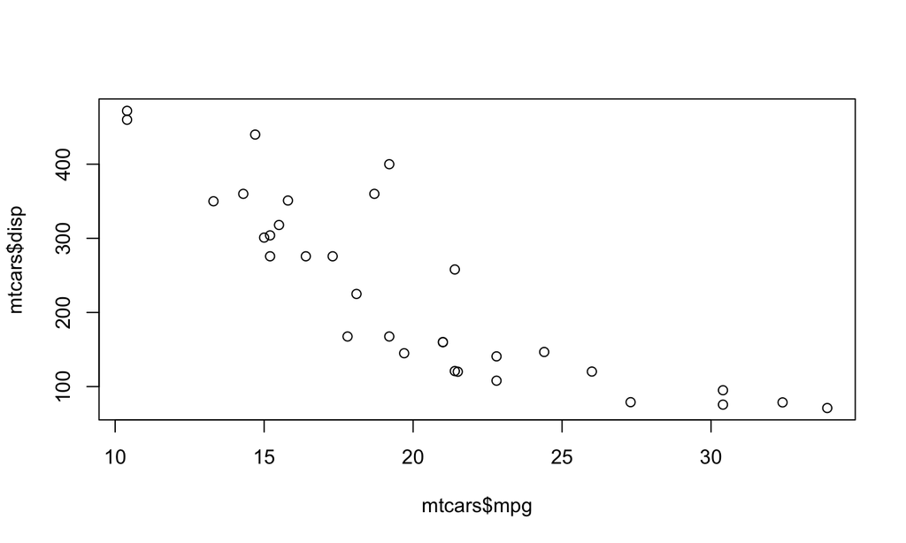

```r
plot(mtcars$mpg, mtcars$disp)
```

## Histograms

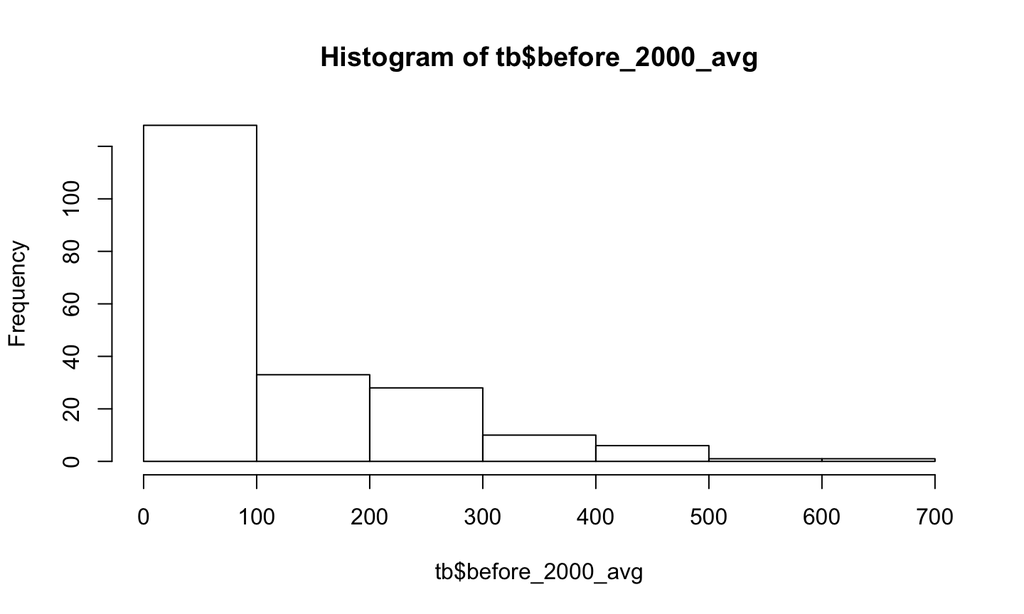

```r
hist(tb$before_2000_avg)
```

## Plot with a line

`type = "l"` means a line

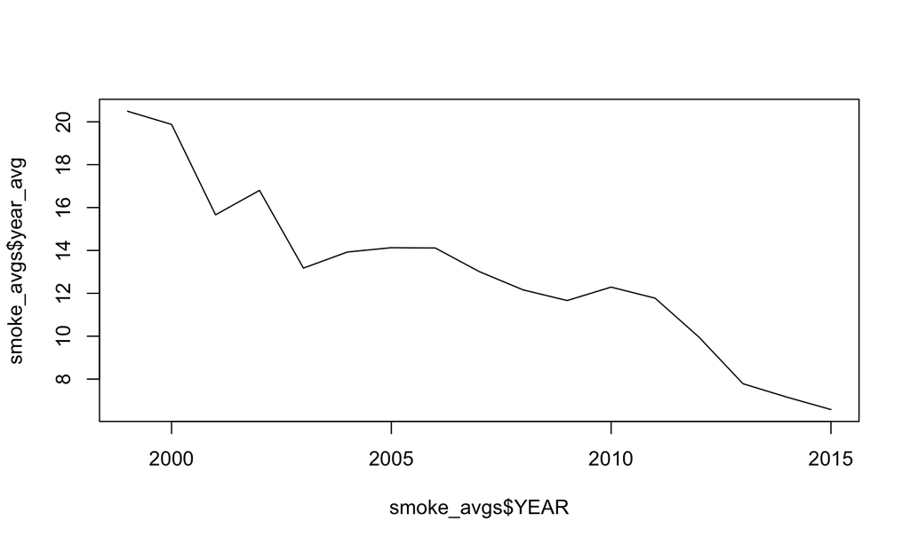

```r
plot(smoke_avgs$YEAR, smoke_avgs$year_avg, type = "l")
```

## Density

Over all years and states, this is the density of smoking status incidence:

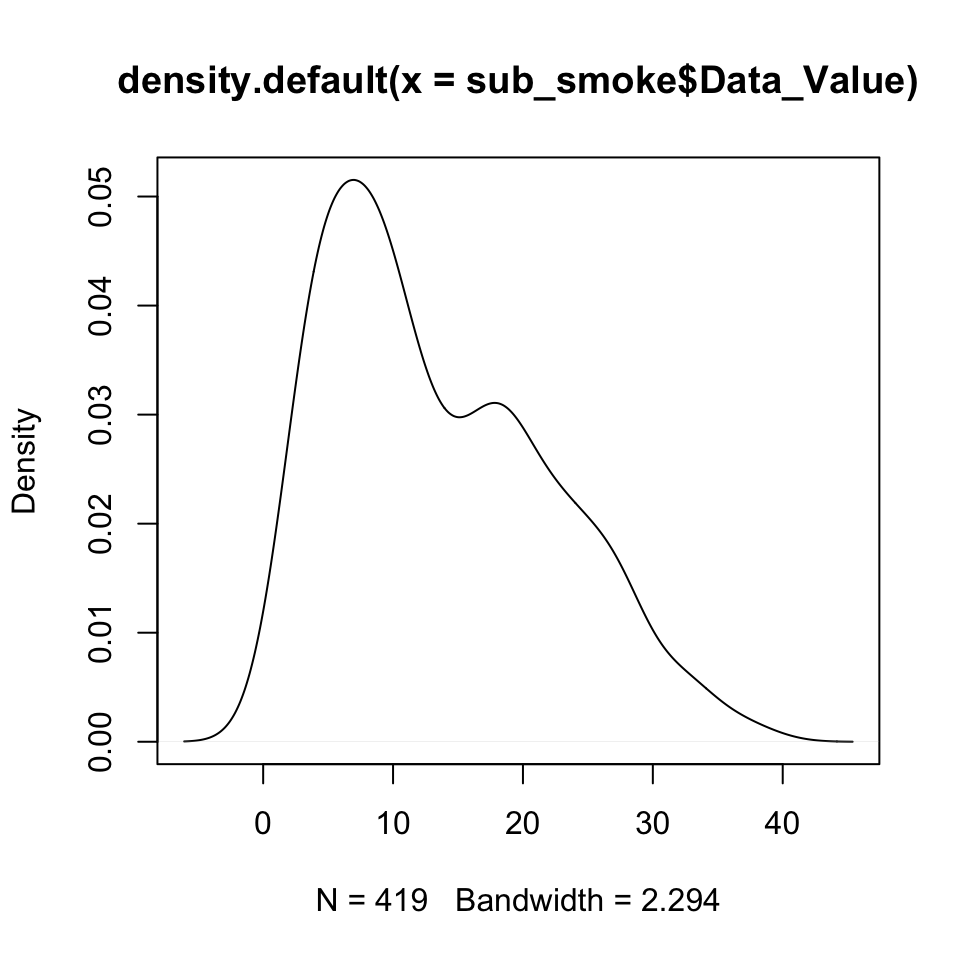

```r
plot(density(sub_smoke$Data_Value))
```

## Boxplots

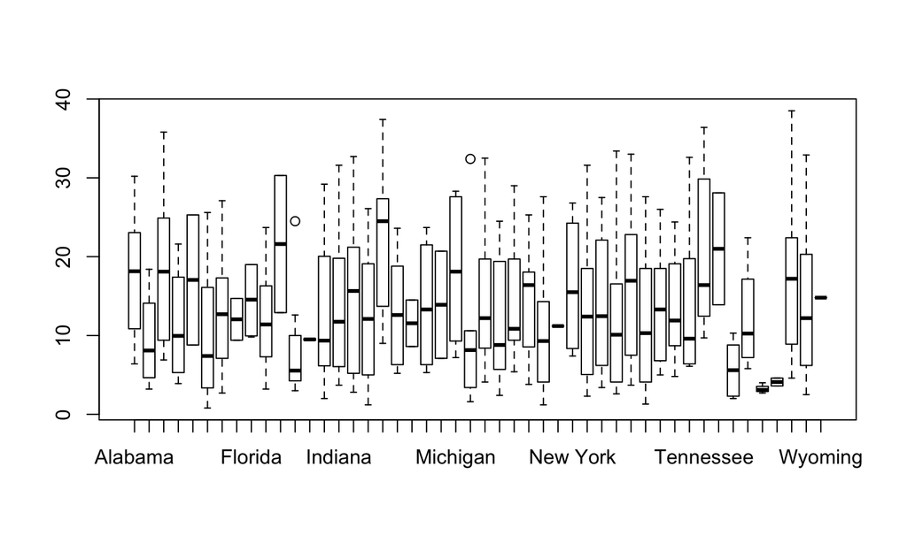

```r
boxplot(sub_smoke$Data_Value ~ sub_smoke$LocationDesc)
```

## Boxplots

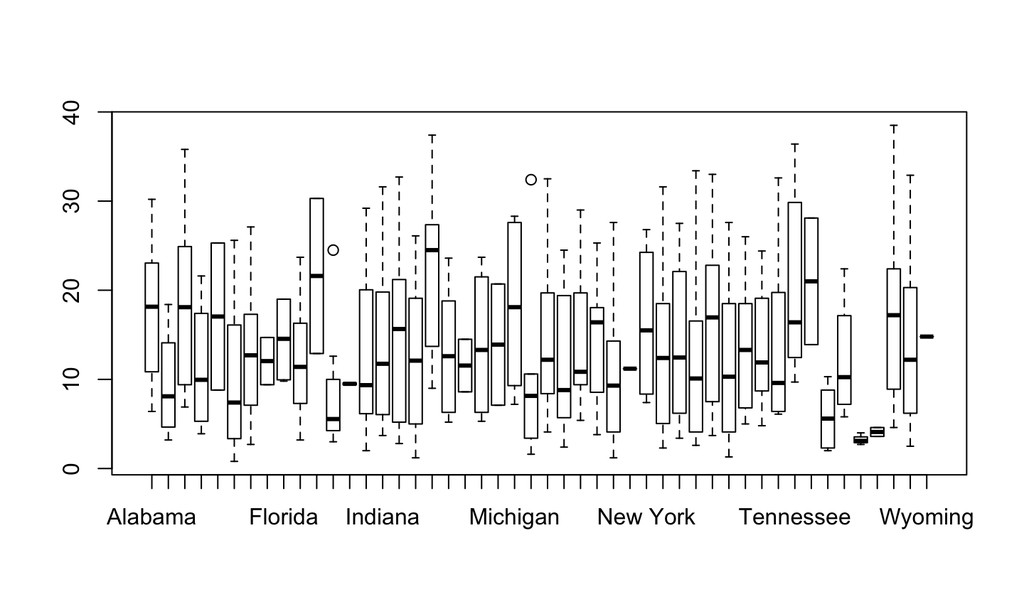

```r
boxplot(Data_Value ~ LocationDesc, data = sub_smoke)
```

## Data Summarization for data.frames

- Basic summarization plots
  - `matplot(x,y)`: scatterplot of two matrices, x and y
  - `pairs(x,y)`: plots pairwise scatter plots of matrices x and y, column by column

## Matrix plot

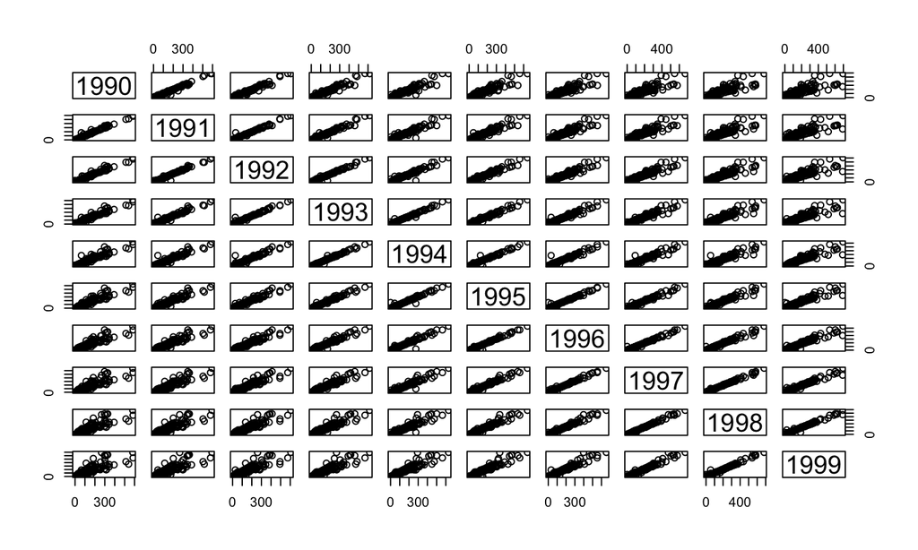

```r
pairs(avgs)
```

## Conclusion

- Base R has apply statements that perform things repeatedly.
- `dplyr` has a lot of more intuitive syntax.
  - `group_by` is very powerful, especilly with `summarise/summarize`
- Base R has good things for quickly summarizing rows or colummns of all numeric data.
  - The `matrixStats` package extends this to `colMedians`, `colMaxs`, etc.